# Corticosterone Data Analysis and Recovery

# Raw data

The data were measured on different time period and among different BXD lines

```r
cort<-read.table("Corticosteroiddata.txt",header=T)
cort
```

| BXD.Lines | Condition | Mice | Replicat.1 | Replicat.2 | pg.ml |
| --- | --- | --- | --- | --- | --- |
| BXD084 | sd | A | 294.467566 | 272.499571 | 283.483568 |
| BXD084 | sd | D | 163.226457 | 173.853899 | 168.540178 |
| BXD084 | sd | B | 139.964525 | 178.718395 | 159.341460 |
| BXD084 | nsd | C | 80.809598 | 70.117547 | 75.463572 |
| BXD084 | nsd | E | 127.328949 | 120.333571 | 123.831260 |
| BXD084 | nsd | I | 60.920182 | 71.607417 | 66.263800 |
| BXD089 | sd | A | 84.501991 | 90.122146 | 87.312069 |
| BXD089 | sd | E | 65.486234 | 77.992688 | 71.739461 |
| BXD089 | sd | B | 131.408693 | 137.955878 | 134.682286 |
| BXD089 | nsd | C | 138.682938 | 132.797452 | 135.740195 |

[output cut: 272 more lines]

The measurement were done between the 14.11.12 & the 23.01.14

- The first problem we see is that the majority of lines measurement were performed into lines-batch (i.g. All BXD50 were done 10.04.13 and not dispatched among batch)
- However, some lines were dispatch among 3 batches (displayed as red color in figures bellow), we could use it to correct for time and cort-control level, taking into account genetic diversity of the lines we observe. Other lines are nested into the batches.

We quickly filter old strains and separate Ctl - SD conditions

```r
cort<-cort[-which(cort$BXD.Lines %in% c("BXD063","BXD029","BXD005","BXD029_TLR4","BXD032")),]
cortNSD<-cort[cort$Condition=="nsd",]
cortSD<-cort[cort$Condition=="sd",]
```

# Heritability computation

```r
# Function to compute heritability

h2Compute<-function(x,y){
  anovares<-aov(x ~ y)
  Va<-summary(anovares)[[1]][1,3]  #is the variance between strains (Mean square for lines effect)
  Vw<-summary(anovares)[[1]][2,3] #is the variance within strains. (Mean square for residuals)
  Vt<-Va+Vw # Total mean variance

  # Broad-sense heritability
  H2<-Va/Vt
  # Narrow-sense heritability
  h2<-0.5*Va/(0.5*Va+Vw)

  return(h2)
}
```

Heritability (narrow sense) using replicates mean

for Ctl:

```r
h2Compute(cortNSD$pg.ml,cortNSD$BXD.Lines)
```

```
## [1] 0.4999169
```

for SD:

```r
h2Compute(cortSD$pg.ml,cortSD$BXD.Lines)
```

```
## [1] 0.6359878
```

The heritability is high ! Especially for SD condition.

If we take the old measurement of Shanaz (the one that she through away, because of bad quality) the heritability is much lower (see bellow) ! So we keep good quality data.

```r
cort_bad<-read.table("Corticosteroiddata_bis.txt",header=T)
cort_bad<-cort_bad[-which(cort_bad$BXD.Lines %in% c("BXD063","BXD029","BXD005","BXD029_TLR4","BXD032")),]
cort_badNSD<-cort_bad[cort_bad$Condition=="nsd",]
cort_badSD<-cort_bad[cort_bad$Condition=="sd",]
h2Compute(cort_badNSD$pg.ml,cort_badNSD$BXD.Lines)
```

```
## [1] 0.3750117
```

```r
h2Compute(cort_badSD$pg.ml,cort_badSD$BXD.Lines)
```

```
## [1] 0.4855017
```

# Outliers detection

Here are the outliers detected by Shanaz scripts:

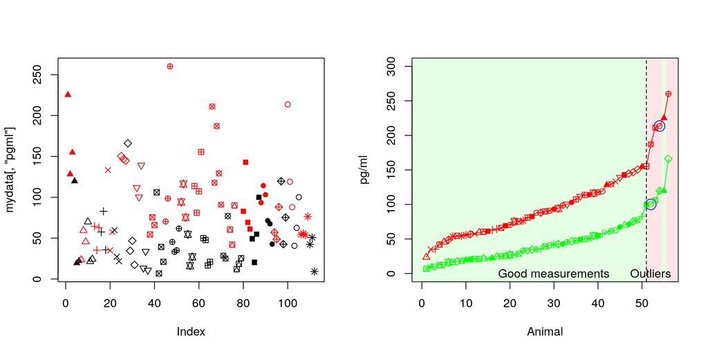

```r
par(mfrow=c(1,2))

mydata <- read.csv("cleaneddata.csv",header=TRUE)

plot(mydata[,"pgml"], col=mydata[,2], pch=as.numeric(as.factor(mydata[,1])))

mock <- which(mydata[,"Type"]=='sd')
affected <- which(mydata[,"Type"]=='nsd')

nAminals <- length(mock)

mocksort <- sort(mydata[mock,"pgml"], index.return = TRUE)
affectedsort <- sort(mydata[affected,"pgml"], index.return = TRUE)

strains <- as.numeric(as.factor(mydata[,1]))

mockStrain <- strains[mock][mocksort$ix]
affectedStrain <- strains[affected][affectedsort$ix]

plot(c(0,nAminals),c(0,300), t='n',ylab='pg/ml',xlab='Animal')
rect(-20,-20,51,320,col=rgb(0,1,0,0.1),lwd=0)  # Background rectangles
rect(54.5,-20,55.5,320,col=rgb(0,1,0,0.1),lwd=0)  # Background rectangles
rect(51,-20,54.5,320,col=rgb(1,0,0,0.1),lwd=0)
rect(55.5,-20,70,320,col=rgb(1,0,0,0.1),lwd=0)

points(54, 213.5638, cex=2,col='blue')
points(52, 100.10015, cex=2,col='blue')

points(mocksort$x, t='l', col='red') # Line
points(mocksort$x, col='red', pch = mockStrain) # points
points(affectedsort$x, t='l',col='green')
points(affectedsort$x,col='green', pch = affectedStrain)

abline(v=51, lty=2, col='black')
text(30,0,"Good measurements")
text(52,0,"Outliers")
```

```r
# I think these ones should be removed
outliersMock <- mydata[mock[mocksort$ix[51:56]],] # Everything in the extreme in the distribution
outliersCleanedMock <- outliersMock[-c(4,5),]     # Keep the ones which look OKAY by genotype

affectedMock <- mydata[affected[affectedsort$ix[51:56]],] # Everything in the extreme in the distribution
affectedCleanedMock <- affectedMock[-c(2,5),]     # Keep the ones which look OKAY by genotype
```

However using the boxplot definition of outlier or a Z-score above 2, we do not really detect outlier (or not enough confident to tell that these are outliers, event if they look alike, even more if we log or square transform the data)

boxplot of the total data

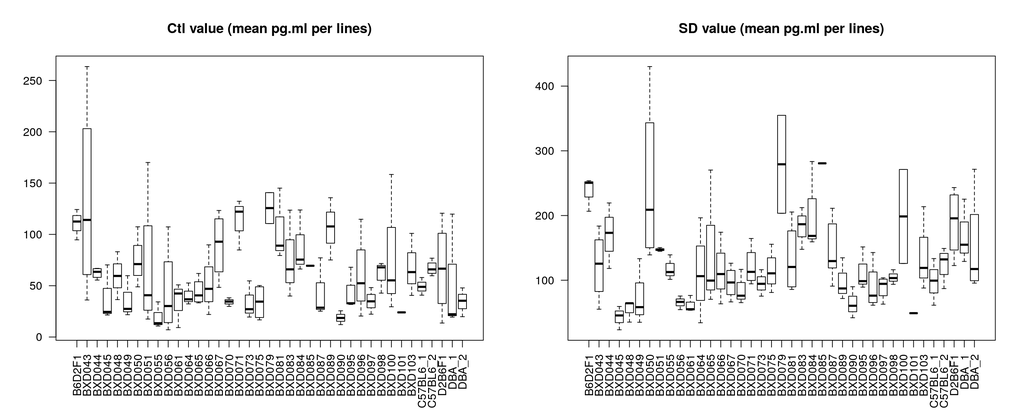

```r
par(mfrow=c(1,2))
boxplot(cortNSD$pg.ml~as.character(cortNSD$BXD.Lines),main="Ctl value (mean pg.ml per lines)",las=2)
boxplot(cortSD$pg.ml~as.character(cortSD$BXD.Lines),main="SD value (mean pg.ml per lines)",las=2)
```

Extreme Zscore (min & max) separated by lines and condition (Ctl & SD result):

```r
quantile(ave(cortNSD$pg.ml, cortNSD$BXD.Lines, FUN=scale),na.rm=T,prob=c(0,1))
```

```
##        0%      100%
## -1.276720  1.477524
```

```r
quantile(ave(cortSD$pg.ml, cortSD$BXD.Lines, FUN=scale),na.rm=T,prob=c(0,1))
```

```
##        0%      100%
## -1.429090  1.494948
```

*We do not see outliers ! (If we consider outlier even as > 1.5 or < -1.5)*

**From Here we keep all data !**

# Comparison of Cort data

Here we compare the cort data with the one in Bernard Thorens lab and the one found in GeneNetwork

```r
# Expression data
CortexNSD<-read.table("htseq-count_summary.txt.NSD.log2CPMnormalizedWITHNSDSD.txt",header=T)

# Filter data for only New strains
Mice<-colnames(CortexNSD)
Mice<-Mice[-c(1,5,6,7,18,39,40,41,42,43,44)]

MeanCortNSD<-aggregate(cortNSD$pg.ml,list(cortNSD$BXD.Lines),mean)
MeanCortSD<-aggregate(cortSD$pg.ml,list(cortSD$BXD.Lines),mean)

MeanCortNSD<-MeanCortNSD[which(MeanCortNSD$Group.1 %in% Mice),]
MeanCortSD<-MeanCortSD[which(MeanCortSD$Group.1 %in% Mice),]

CortlvlNSD<-MeanCortNSD$x
names(CortlvlNSD)<-MeanCortNSD$Group.1
CortlvlNSD<-CortlvlNSD[Mice]

CortlvlSD<-MeanCortSD$x
names(CortlvlSD)<-MeanCortSD$Group.1
CortlvlSD<-CortlvlSD[Mice]
```

We compare the cort level in our Control (Non-sleep-deprived) with their data using NaCl injection

The second plot is identical, the color represent the different batches

```r
# Set colors
Oldanalysis<-c("BXD045","BXD048","BXD049","BXD051","BXD055","BXD056","BXD065","BXD073","BXD075","BXD087","BXD090","BXD096","BXD098","BXD063","BXD103","BXD061")
Oldanalysis13<-c("BXD050","BXD064","BXD070","BXD081","BXD100")
Oldanalysis14<-c("BXD066","BXD067","BXD071","BXD079","BXD085")
Oldanalysis15<-c("BXD043","BXD044","BXD083")
Oldanalysis16<-c("BXD084","BXD089","BXD095")
col<-rep('black',length(CortlvlNSD))
col[names(CortlvlNSD) %in% Oldanalysis]<-'red'
col[names(CortlvlNSD) %in% Oldanalysis13]<-'green'
col[names(CortlvlNSD) %in% Oldanalysis14]<-'blue'
col[names(CortlvlNSD) %in% Oldanalysis15]<-'orange'
col[names(CortlvlNSD) %in% Oldanalysis16]<-'purple'
```

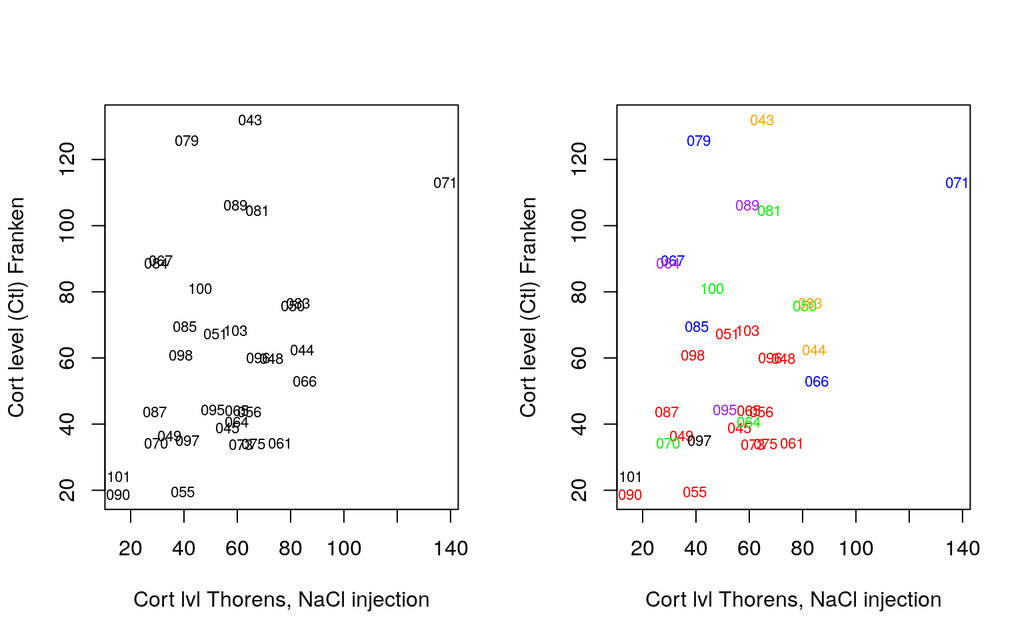

```r
x<-read.table("CortData_Thorens.txt",header=T,sep="\t")
rownames(x)<-x$X.format.column
rownames(x)<-gsub("BXD","BXD0",rownames(x))
rownames(x)[which(rownames(x)=="BXD048a")]<-"BXD096"
rownames(x)[which(rownames(x)=="BXD073b")]<-"BXD103"
rownames(x)[which(rownames(x)=="BXD065a")]<-"BXD097"
rownames(x)<-gsub("BXD010","BXD10",rownames(x))
x<-x[which(rownames(x) %in% Mice), ]

x<-x[names(CortlvlSD),]

par(mfrow=c(1,2))
plot(x$cort.nacl,CortlvlNSD,ylab="Cort level (Ctl) Franken",xlab="Cort lvl Thorens, NaCl injection",cex=.1,col=rgb(0,0,0,0))
text(x$cort.nacl,CortlvlNSD,labels=gsub("BXD","",Mice),cex=.7)

plot(x$cort.nacl,CortlvlNSD,ylab="Cort level (Ctl) Franken",xlab="Cort lvl Thorens, NaCl injection",cex=.1,col=rgb(0,0,0,0))
text(x$cort.nacl,CortlvlNSD,labels=gsub("BXD","",Mice),cex=.7,col=col)
```

The same but with data from GeneNetwork: (ID: 12567)

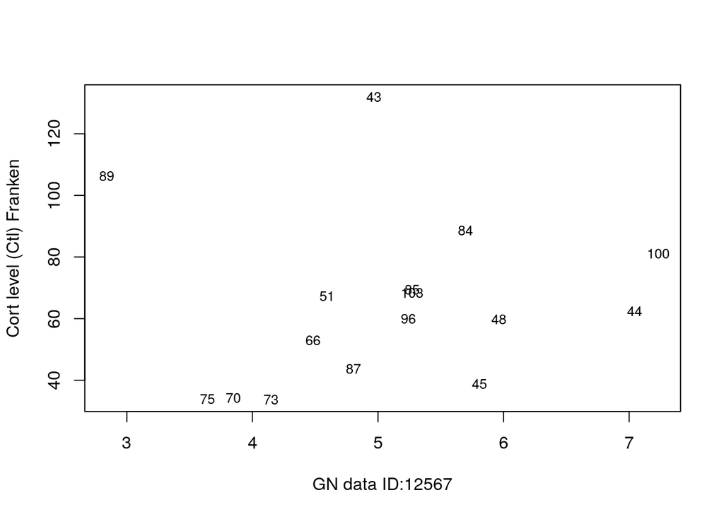

```r
GNdata<-read.table("GeneNetwork_CorticoLevel_ID_12567.txt")
GNdata<-GNdata[-which(GNdata$V2=='x'),]

GNdata_v<-as.numeric(as.character(GNdata$V2))
names(GNdata_v)<-GNdata$V1
names(CortlvlNSD)<-gsub("BXD0","BXD",names(CortlvlNSD))

nsh<-names(GNdata_v)[names(GNdata_v) %in% names(CortlvlNSD)]

plot(GNdata_v[nsh],CortlvlNSD[nsh],xlab="GN data ID:12567",ylab="Cort level (Ctl) Franken",cex=.1,col=rgb(0,0,0,0))
text(GNdata_v[nsh],CortlvlNSD[nsh],labels=gsub("BXD","",nsh),cex=.8)
```

# Batch effect

We saw above that some batch (e.g. red) have a lower cort level than other (e.g. orange, green)

We can more clearly see this using only mean values:

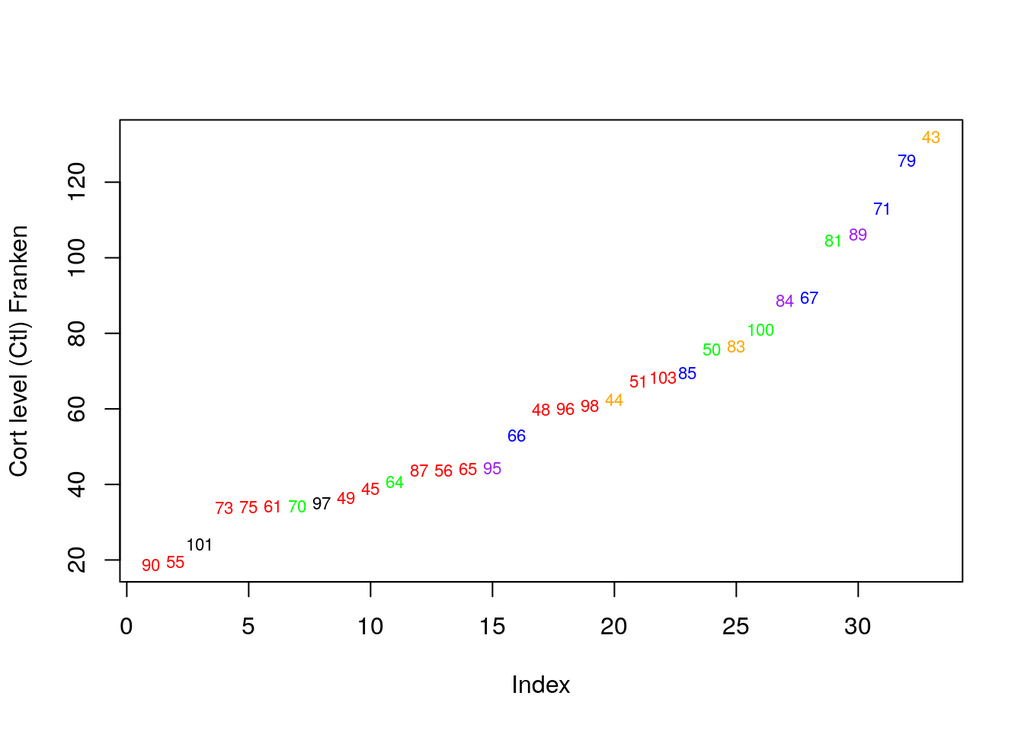

```r
plot(sort(CortlvlNSD),col=rgb(0,0,0,0),ylab="Cort level (Ctl) Franken")
text(seq(1,length(CortlvlNSD)),CortlvlNSD[order(CortlvlNSD)],labels=gsub("BXD","",names(CortlvlNSD))[order(CortlvlNSD)],cex=.7,col=col[order(CortlvlNSD)])
```

The difference between batches is significant !

```r
lmCoNSD<-summary(aov(CortlvlNSD~col))
lmCoNSD
```

```
##             Df Sum Sq Mean Sq F value  Pr(>F)
## col          5  14265  2853.0       5 0.00228 **
## Residuals   27  15407   570.6
## ---
## Signif. codes:  0 '***' 0.001 '**' 0.01 '*' 0.05 '.' 0.1 ' ' 1
```

It looks like the higher the control cort level is, the higher the level of cort in BXD lines will be (p<5.01e-05)

Higher Cort control seems also to increase data dispersion

```r
CortCtl<-col
CortCtl[col=="green"]<-111.99
CortCtl[col=="blue"]<-129.51
CortCtl[col=="orange"]<-182.97
CortCtl[col=="orange"]<-182.97
CortCtl[col=="red"]<-mean(c(78,53,60))
CortCtl[col=="purple"]<-141.81
CortCtl[col=="black"]<-66.04
CortCtl<-as.numeric(CortCtl)

lmCoNSD<-summary(lm(CortlvlNSD~CortCtl))
lmCoNSD
```

```
##
## Call:
## lm(formula = CortlvlNSD ~ CortCtl)
##
## Residuals:
##     Min      1Q  Median      3Q     Max
## -39.285 -21.188  -0.422  15.927  49.802
##
## Coefficients:
##             Estimate Std. Error t value Pr(>|t|)
## (Intercept)  13.3404    10.9652   1.217    0.233
## CortCtl       0.4827     0.1026   4.704 5.01e-05 ***
## ---
## Signif. codes:  0 '***' 0.001 '**' 0.01 '*' 0.05 '.' 0.1 ' ' 1
##
## Residual standard error: 23.63 on 31 degrees of freedom
## Multiple R-squared:  0.4165, Adjusted R-squared:  0.3977
## F-statistic: 22.13 on 1 and 31 DF,  p-value: 5.01e-05
```

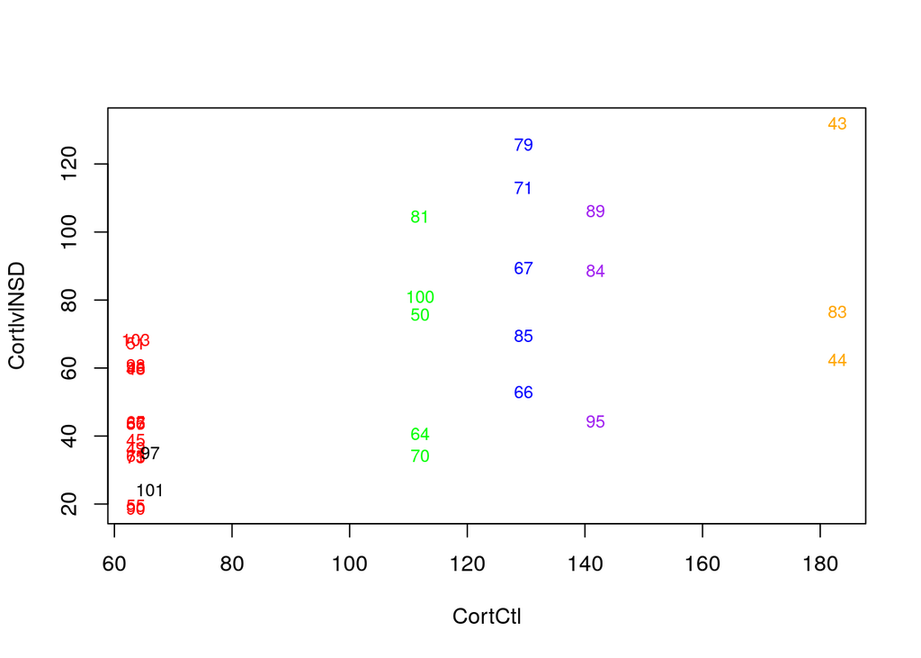

```r
plot(CortCtl,CortlvlNSD,col=rgb(0,0,0,0),pch=19)
text(CortCtl,CortlvlNSD,labels=gsub("BXD","",names(CortlvlNSD)),cex=.8,col=col)
```

But what is lines effect and batch effect ?

# Batch effect correction

Let’s try to correct the batch effect using the ‘red’ batch. Within the red batch, the lines were recorded among 3 distinct batch, the data are not nested ! So we take into account the lines effect and cort control effect.

```r
# Read the batcheffectFile.txt, generated by and from the xlsx file
library(xlsx)
res <- read.xlsx("BatchEffect.xlsx", 1) # read the second sheet
cortF<-read.table("Corticosteroiddata.txt",header=T)

# Attribute line factor column
lines<-as.character(cortF$BXD.Lines)
names(lines)<-paste(gsub("BXD0","",lines),cortF$Mice,sep='')
names(lines)<-gsub("BXD",'',names(lines))

res$lines<-lines[as.character(res$Mice)]

# Attribute Condition
cond<-as.character(cortF$Condition)
names(cond)<-paste(gsub("BXD0","",as.character(cortF$BXD.Lines)),cortF$Mice,sep='')
names(cond)<-gsub("BXD",'',names(cond))
res$Condition<-cond[as.character(res$Mice)]

# Data removed it seems... no info
res<-res[-108,]
```

Fit model

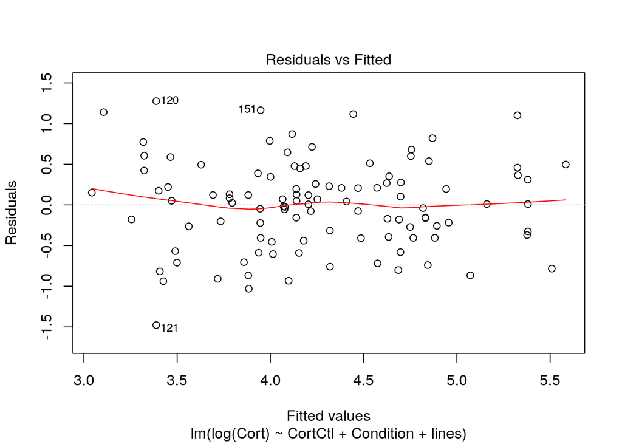

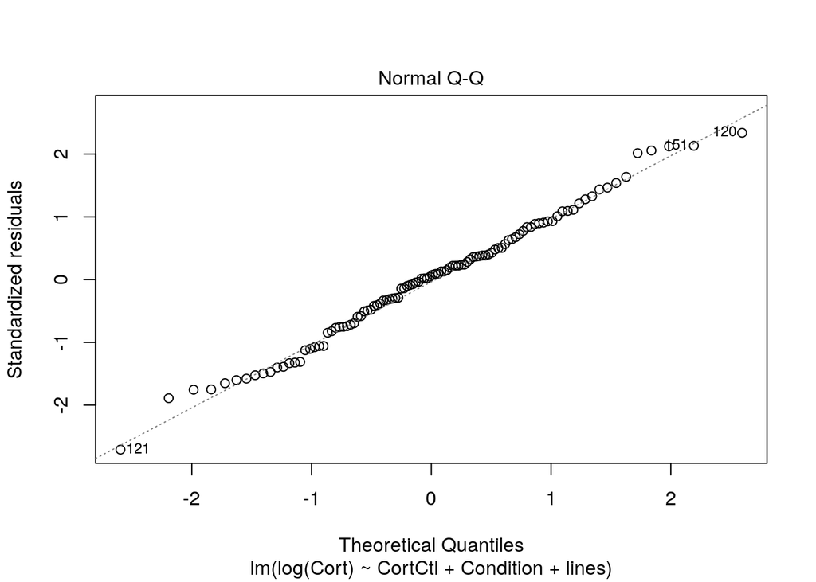

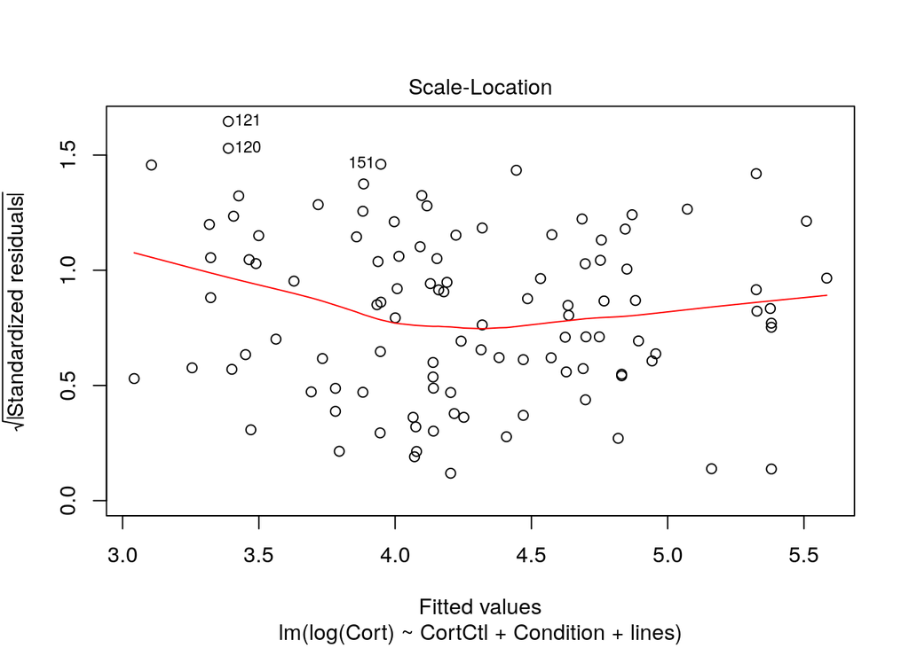

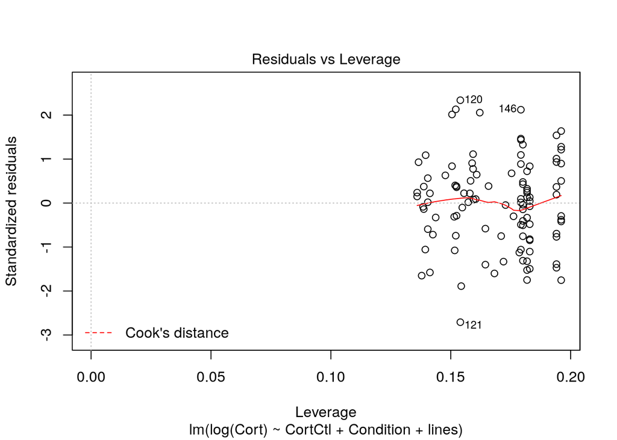

```r
res2<-res[-which(res$Batch %in% c("Batch1","Batch2")),]
#res2<-res
fit<-lm(log(Cort)~CortCtl+Condition+lines,data=res2)
plot(fit)
```

```r
sfit<-summary(fit)

slope<-sfit$coefficients["CortCtl","Estimate"]
slope
```

```
## [1] 0.009328431
```

Estimate Cort level

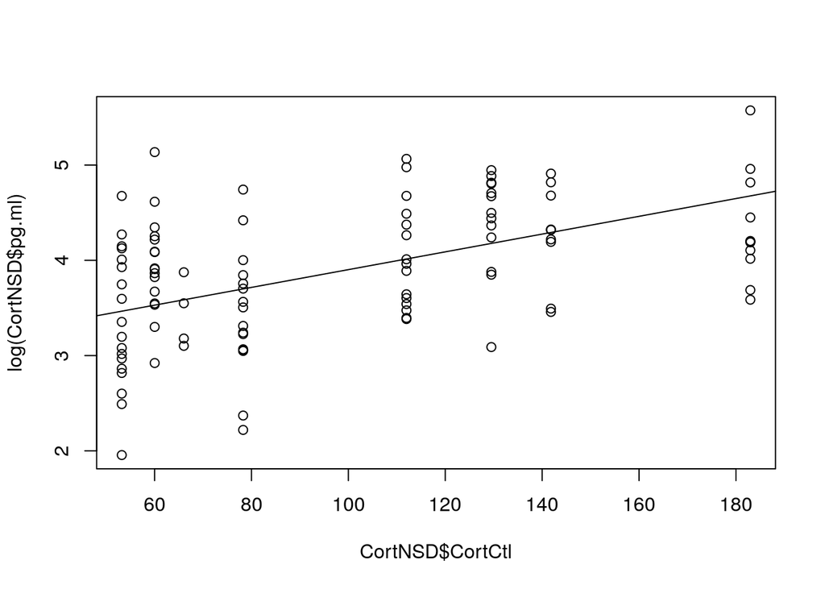

```r
## Add Cort Control to cort dataset
names(CortCtl)<- names(CortlvlSD)
cort$CortCtl<-rep(NA,nrow(cort))
for (i in 1:nrow(cort)){
  if (as.character(cort[i,"BXD.Lines"]) %in% names(CortCtl)){
    cort[i,"CortCtl"]<-CortCtl[as.character(cort[i,"BXD.Lines"])]
  }
}

res2<-res[-which(res$Batch %in% c("Batch1bis","Batch2")),]
res2$MiceID<-sub("([0-9]+)","" ,res2$Mice)

for (i in 1:nrow(res2)){
  cort[as.character(cort$BXD.Lines)==res2[i,"lines"] & as.character(cort$Mice)==res2[i,"MiceID"],"CortCtl"]<-res2[i,"CortCtl"]
}

cort <- cort[! is.na(cort$CortCtl),]

#### for Ctl
CortNSD<-cort[cort$Condition=="nsd",]
fit_fixedslope<-lm(log(CortNSD$pg.ml) - slope*CortNSD$CortCtl ~ 1)
intercept<-fit_fixedslope$coefficients

plot(CortNSD$CortCtl,log(CortNSD$pg.ml))
abline(a=intercept,b=slope)
```

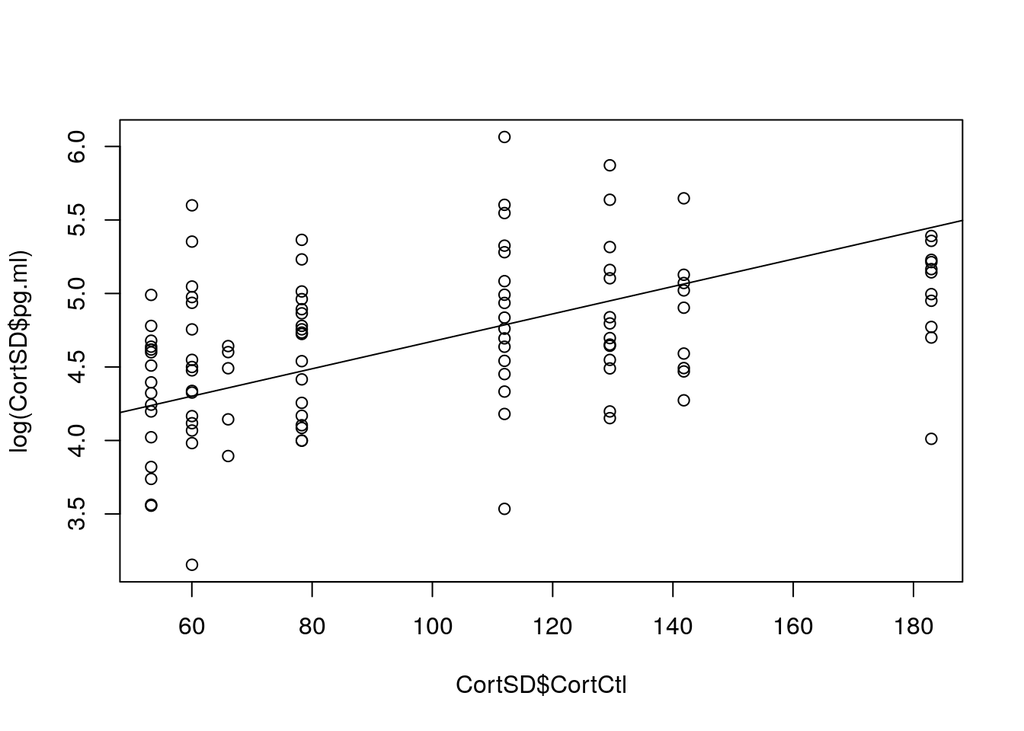

```r
EstimatedCortLevel_Ctl<-exp(intercept+60*slope+fit_fixedslope$residuals)
EstimatedCortLevel_Ctl_mean<-aggregate(EstimatedCortLevel_Ctl,list(CortNSD$BXD.Lines),mean)

# a<-EstimatedCortLevel_Ctl
# names(a)<-CortNSD$BXD.Lines
# a

n<-as.character(EstimatedCortLevel_Ctl_mean$Group.1)
EstimatedCortLevel_Ctl_mean<-EstimatedCortLevel_Ctl_mean$x
names(EstimatedCortLevel_Ctl_mean)<-n
EstimatedCortLevel_Ctl_mean<-EstimatedCortLevel_Ctl_mean[names(CortlvlSD)]

#### for SD
CortSD<-cort[cort$Condition=="sd",]
fit_fixedslope<-lm(log(CortSD$pg.ml) - slope*CortSD$CortCtl ~ 1)
intercept<-fit_fixedslope$coefficients

plot(CortSD$CortCtl,log(CortSD$pg.ml))
abline(a=intercept,b=slope)
```

```r
EstimatedCortLevel_SD<-exp(intercept+60*slope+fit_fixedslope$residuals)
EstimatedCortLevel_SD_mean<-aggregate(EstimatedCortLevel_SD,list(CortSD$BXD.Lines),mean)
n<-as.character(EstimatedCortLevel_SD_mean$Group.1)
EstimatedCortLevel_SD_mean<-EstimatedCortLevel_SD_mean$x
names(EstimatedCortLevel_SD_mean)<-n
EstimatedCortLevel_SD_mean<-EstimatedCortLevel_SD_mean[names(CortlvlSD)]
```

Compare with Raw data

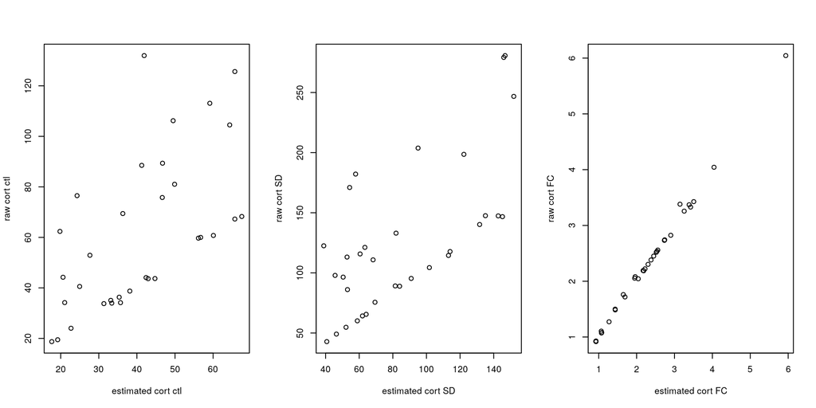

```r
par(mfrow=c(1,3))
plot(EstimatedCortLevel_Ctl_mean,CortlvlNSD,xlab="estimated cort ctl",ylab="raw cort ctl")
plot(EstimatedCortLevel_SD_mean,CortlvlSD,xlab="estimated cort SD",ylab="raw cort SD")
plot(EstimatedCortLevel_SD_mean/EstimatedCortLevel_Ctl_mean,CortlvlSD/CortlvlNSD,xlab="estimated cort FC",ylab="raw cort FC")
```

Compare with Thorens

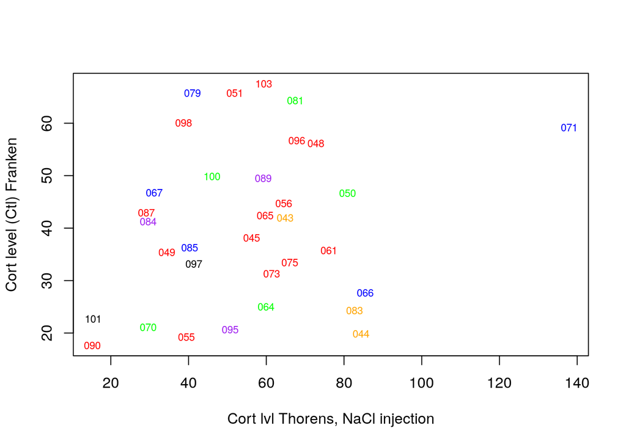

```r
names(EstimatedCortLevel_Ctl_mean)<-names(CortlvlNSD)
plot(x$cort.nacl,EstimatedCortLevel_Ctl_mean,ylab="Cort level (Ctl) Franken",xlab="Cort lvl Thorens, NaCl injection",cex=.1,col=rgb(0,0,0,0))
text(x$cort.nacl,EstimatedCortLevel_Ctl_mean,labels=gsub("BXD","",Mice),cex=.7,col=col)
```

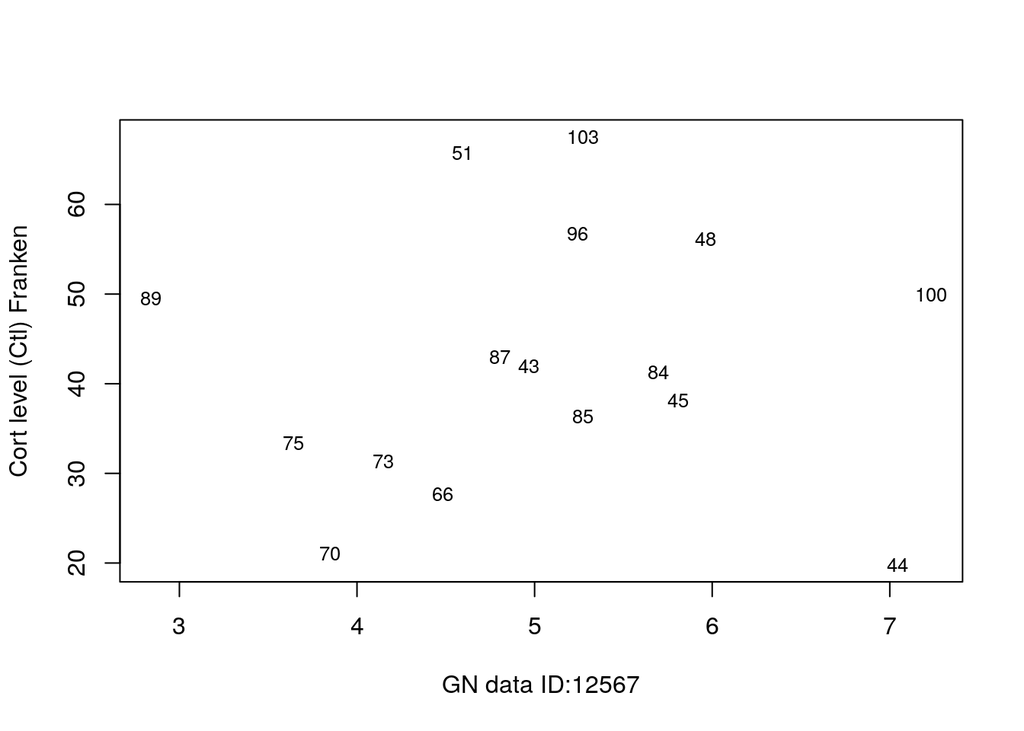

```r
plot(GNdata_v[nsh],EstimatedCortLevel_Ctl_mean[nsh],xlab="GN data ID:12567",ylab="Cort level (Ctl) Franken",cex=.1,col=rgb(0,0,0,0))
text(GNdata_v[nsh],EstimatedCortLevel_Ctl_mean[nsh],labels=gsub("BXD","",nsh),cex=.8)
```

```r
cor.test(x$cort.nacl,EstimatedCortLevel_Ctl_mean)
```

```
##
##  Pearson's product-moment correlation
##
## data:  x$cort.nacl and EstimatedCortLevel_Ctl_mean
## t = 1.2792, df = 31, p-value = 0.2103
## alternative hypothesis: true correlation is not equal to 0
## 95 percent confidence interval:
##  -0.1293419  0.5267289
## sample estimates:
##       cor
## 0.2239097
```